# EAS509 Final Exam

Submit your answers as a single pdf attach all R code. Failure to do so will result in grade reduction.

The exam must be done individually, with no discussion or help with others. Breaking this rule will result in an automatic 0 grade.

# Part A (30 points) - each question worth 1 points

Some questions have multiple answers

1. Which simple forecasting method says the forecast is equal to the mean of the historical data?
1. Average Method
2. Naïve Method
3. Seasonal Naïve Method
4. Drift Method

**Answer:a. Average Method**

2. Which simple forecasting method says the forecast is equal to the last observed value?
1. Average Method
2. Naïve Method
3. Seasonal Naïve Method
4. Drift Method

**Answer:b. Naïve Method**

3. Which simple forecasting method is equivalent to extrapolating a line draw between the first and lost observations?
1. Average Method
2. Naïve Method
3. Seasonal Naïve Method
4. Drift Method

**Answer:d. Drift Method**

4. Which of the following is an assumption made about forecasting residuals during point forecast?
1. Residuals are normally distributed
2. Residuals are uncorrelated
3. Residuals have constant variance
4. None of the above

**Answer: b. Residuals are uncorrelated**

5. Which of the following is an assumption made about forecasting residuals during interval forecasting? (multiple answers)
1. Residuals have mean zero
2. Residuals are normally distributed
3. Residuals have constant variance
4. None of the above

**Answer:a. Residuals have mean zero,b. Residuals are normally distributed & c. Residuals have constant variance** all should present for full score

6. What is the consequence of forecasting residuals that are not uncorrelated?
1. Prediction intervals are difficult to calculate
2. Information is left in the residuals that should be used
3. Forecasts are biased
4. None of the above

**Answer: b. Information is left in the residuals that should be used**

7. What is the consequence of forecasting residuals that don’t have mean zero?
1. Prediction intervals are difficult to calculate
2. Information is left in the residuals that should be used
3. Forecasts are biased
4. None of the above

**Answer: c. Forecasts are biased**

8. Which measure of forecast accuracy is scale independent?
1. MAE
2. MSE
3. RMSE
4. MAPE

**Answer: d. MAPE**

9. Calculation of forecasts is based on what?
1. Test set
2. Training set
3. Both
4. Neither

**Answer: b. Training set**

10. Forecast accuracy is based on what?
1. Test set
2. Training set
3. Both
4. Neeither

**Answer: a. Test set**

11. A series that is influenced by seasonal factors is known as what?
1. Trend
2. Seasonal
3. Cyclical
4. White Noise

**Answer: b. Seasonal**

12. Data that exhibits rises and falls that are not of a fixed period is known as what?
1. Trend
2. Seasonal
3. Cyclical
4. White Noise

**Answer: a. Trend & c. Cyclicale** either or all is ok for full credit

13. Data that is uncorrelated over time is known as what?
1. Trend
2. Seasonal
3. Cyclical
4. White Noise

**Answer: d. White Noise**

14. Which of the following time series decomposition models is appropriate when the magnitude of the seasonal fluctuations are not proportional to the level?
1. Additive
2. Multiplicative
3. Both
4. Neither

**Answer: a. Additive**

15. Which of the following time series decomposition models is appropriate when the magnitude of the seasonal fluctuations are proportional to the level?
1. Additive
2. Multiplicative
3. Both
4. Neither

**Answer: b. Multiplicative**

Exhibit 1

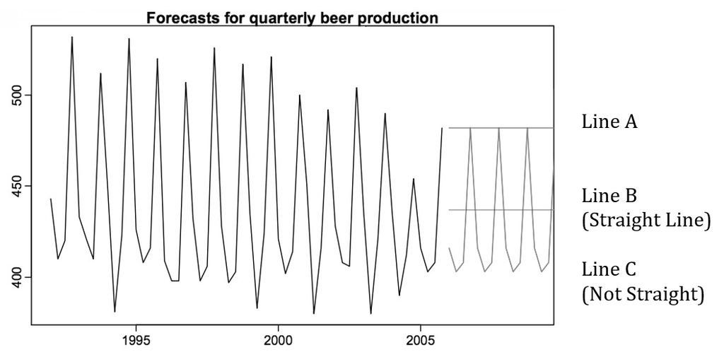

16. Refer to Exhibit 1. Line A is which simple forecasting method?CHECK
1. Average Method
2. Naïve Method
3. Seasonal Naïve Method
4. Drift

**Answer: b. Naïve Method**

17. Refer to Exhibit 1. Line B is which simple forecasting method?cHECK
1. Average Method
2. Naïve Method
3. Seasonal Naïve Method
4. Drift Method

**Answer: a. Average Method**

18. Refer to Exhibit 1. Line C is which simple forecasting method?CHECK
1. Average Method
2. Naïve Method
3. Seasonal Naïve Method
4. Drift Method

**Answer: c. Seasonal Naïve Method**

Exhibit 2

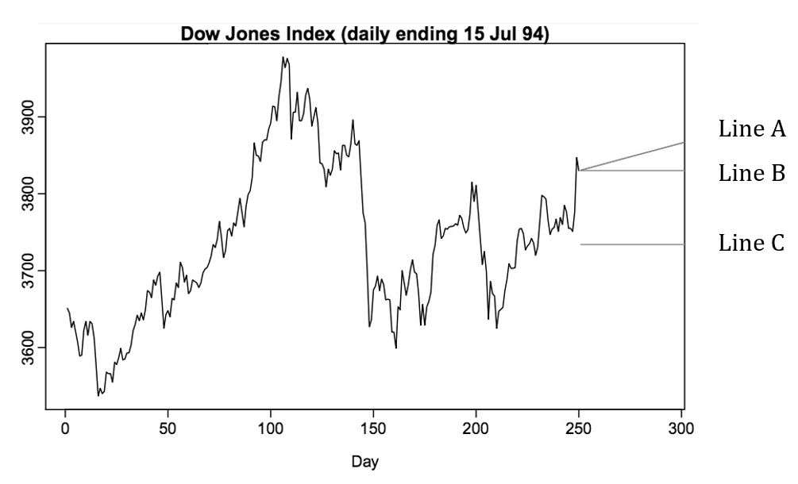

19. Refer to Exhibit 2. Line A is which simple forecasting method?
1. Average Method
2. Naïve Method
3. Seasonal Naïve Method
4. Drift Method

**Answer: d. Drift Method**

20. Refer to Exhibit 2. Line B is which simple forecasting method?
1. Average Method
2. Naïve Method
3. Seasonal Naïve Method
4. Drift Method

**Answer: b. Naïve Method**

21. Refer to Exhibit 2. Line C is which simple forecasting method?
1. Average Method
2. Naïve Method
3. Seasonal Naïve Method
4. Drift Method

**Answer: a. Average Method**

Exhibit 3

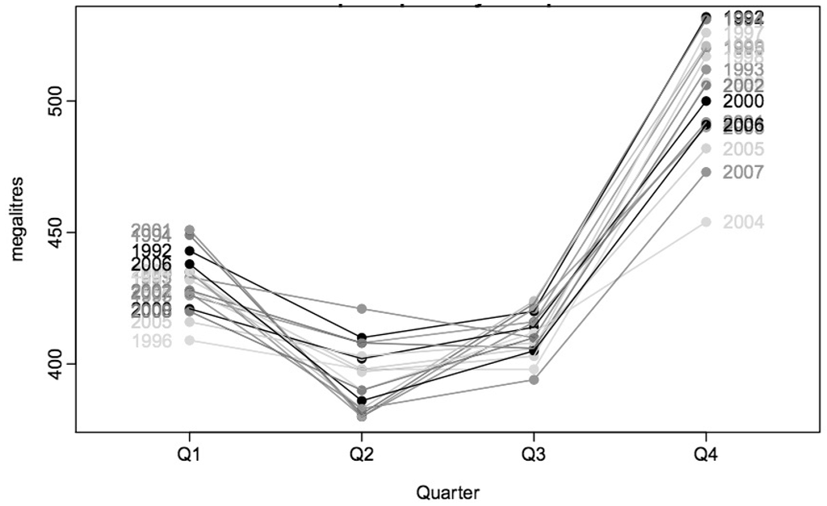

22. Refer to Exhibit 3. The peaks are in which quarter?
1. Quarter 1
2. Quarter 2
3. Quarter 3
4. Quarter 4

**Answer: d. Quarter 4**

23. Refer to Exhibit 3. The trough are in which quarter?
1. Quarter 1
2. Quarter 2
3. Quarter 3
4. Quarter 4

**Answer: b. Quarter 2** there are few in Q3 but largly it is Q2

Exhibit 4

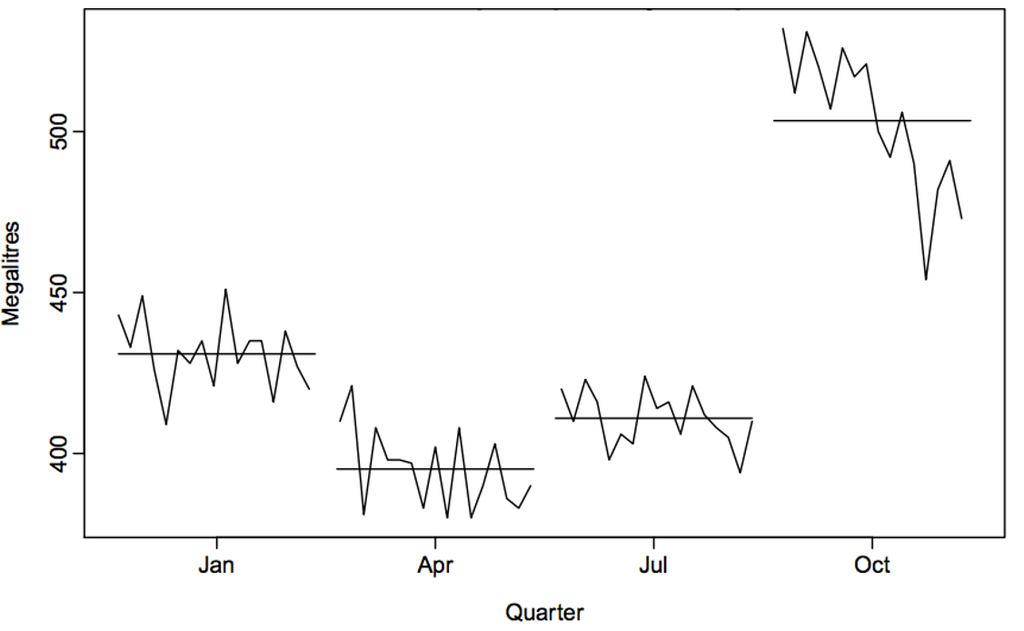

24. Refer to Exhibit 4. The peaks are in which quarter?
1. Quarter 1
2. Quarter 2
3. Quarter 3
4. Quarter 4

**Answer: d. Quarter 4**

25. Refer to Exhibit 4. The trough are in which quarter?
1. Quarter 1
2. Quarter 2
3. Quarter 3
4. Quarter 4

**Answer: b. Quarter 2**

26. Refer to Exhibit 4. In which quarter is there a decline in the seasonal affect?
1. Quarter 1
2. Quarter 2
3. Quarter 3
4. Quarter 4

**Answer: d. Quarter 4**

Figure 5

| Year 1 |  |  |  | Year 2 |  |  |  |
| --- | --- | --- | --- | --- | --- | --- | --- |
| Q1 | Q2 | Q3 | Q4 | Q1 | Q2 | Q3 | Q4 |
| 10 | 6 | 8 | 12 | 11 | 7 | 9 | 13 |

27. Refer to Figure 5. Using the average method, what is the forecast of Quarter 2 of Year 3? (Don’t use a calculator.)
1. 7
2. 9.5
3. 13.85
4. 13

**Answer: b. 9.5**

28. Refer to Figure 5. Using the naïve method, what is the forecast of Quarter 2 of Year 3? (Don’t use a calculator.)
1. 7
2. 9.5
3. 13.85
4. 13

**Answer:d. 13**

# Part B (30 points)

Choose a series from us_employment.cvs, the total employment in leisure and hospitality industry in the United States (see, title column).

1. Produce an STL decomposition of the data and describe the trend and seasonality. (4 points)

```r
# I am reading the data of Lesiure and hospitality industry
data <- fread('us_employment.cvs')
us_employemnt <- data[Title == 'Leisure and Hospitality']
head(us_employemnt)
```

| Month | Series_ID | Title | Employed |
| --- | --- | --- | --- |
| 1939 Jan | CEU7000000001 | Leisure and Hospitality | 1807 |
| 1939 Feb | CEU7000000001 | Leisure and Hospitality | 1804 |
| 1939 Mar | CEU7000000001 | Leisure and Hospitality | 1834 |
| 1939 Apr | CEU7000000001 | Leisure and Hospitality | 1863 |
| 1939 May | CEU7000000001 | Leisure and Hospitality | 1882 |
| 1939 Jun | CEU7000000001 | Leisure and Hospitality | 1894 |

```r
#Now lets convert the data into timeseries.

us_employemnt_TS <- us_employemnt %>%
  select(Month, Employed) %>%
  mutate(Month = yearmonth(Month)) %>%
  as_tsibble(index = Month)

head(us_employemnt_TS)
```

| Month | Employed |
| --- | --- |
| 1939 Jan | 1807 |
| 1939 Feb | 1804 |
| 1939 Mar | 1834 |
| 1939 Apr | 1863 |
| 1939 May | 1882 |
| 1939 Jun | 1894 |

[figure not shown]

```r
#Before Decomposition Plot
us_employemnt_TS %>%
  autoplot(Employed) +
  labs(
    y = "Persons (thousands)",
    title = "Total employment in US retail"
  )
```

```r
#STL Decomposition
us_emp_dcmp <- us_employemnt_TS %>%
  model(stl = STL(Employed))
components(us_emp_dcmp)
```

| .model | Month | Employed | trend | season_year | remainder | season_adjust |
| --- | --- | --- | --- | --- | --- | --- |
| stl | 1939 Jan | 1807 | 1861.334 | -49.7893578 | -4.54507296 | 1856.789 |
| stl | 1939 Feb | 1804 | 1867.789 | -62.8157179 | -0.97345932 | 1866.816 |
| stl | 1939 Mar | 1834 | 1874.244 | -35.4743369 | -4.76958670 | 1869.474 |
| stl | 1939 Apr | 1863 | 1880.699 | -17.2346080 | -0.46406198 | 1880.235 |
| stl | 1939 May | 1882 | 1887.277 | -15.5294924 | 10.25222975 | 1897.529 |
| stl | 1939 Jun | 1894 | 1893.856 | -9.1752696 | 9.31941436 | 1903.175 |
| stl | 1939 Jul | 1873 | 1900.434 | -33.8612381 | 6.42679022 | 1906.861 |
| stl | 1939 Aug | 1868 | 1907.283 | -41.3780216 | 2.09476668 | 1909.378 |
| stl | 1939 Sep | 1920 | 1914.132 | -2.2614341 | 8.12937214 | 1922.261 |
| stl | 1939 Oct | 1938 | 1920.981 | 26.6190104 | -9.59987935 | 1911.381 |

[output cut: 959 more lines]

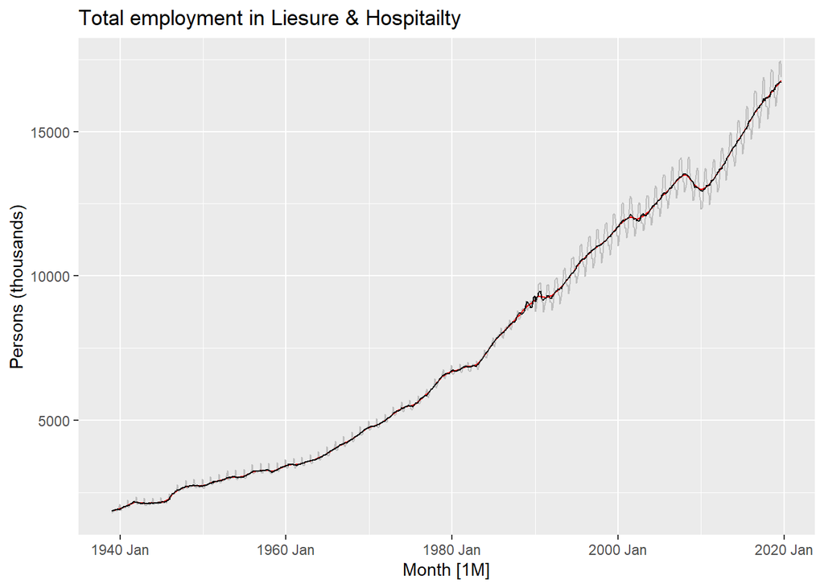

```r
#After Decomposition Plot
us_employemnt_TS %>%
  autoplot(Employed, color = "gray") +
  autolayer(components(us_emp_dcmp), trend, color = "red") +
  autolayer(components(us_emp_dcmp), season_adjust, color = "black") +
  labs(
    y = "Persons (thousands)",
    title = "Total employment in Liesure & Hospitailty"
  )
```

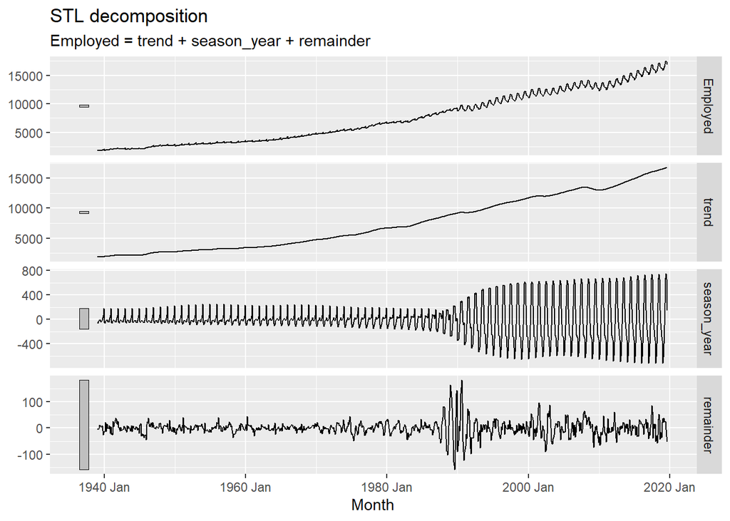

```r
components(us_emp_dcmp) %>% autoplot()
```

#The trend is increasing over years but we can see some drops in between 2002 and 2010. And in the initial years from 1940 to 1989, we cant see much variations in seasionality, but later especially in 1990 we can see the seasonnality is maximum. b. Do the data need transforming? If so, find a suitable transformation.(4 points)

```r
us_employemnt_TS %>%
  features(Employed, features = guerrero)
```

| lambda_guerrero |
| --- |
| -0.2164477 |

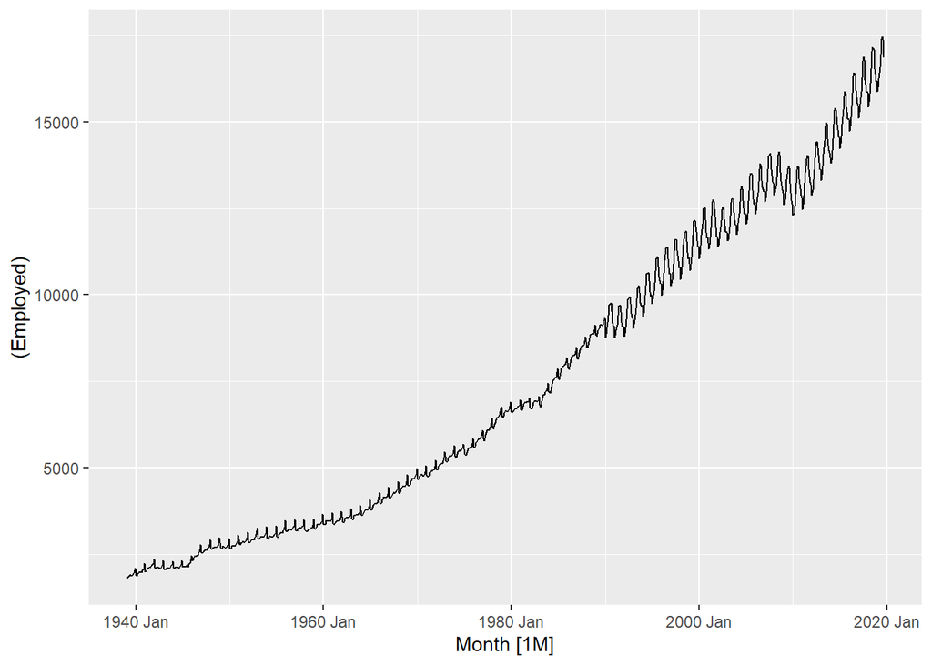

```r
us_employemnt_TS %>% autoplot((Employed))
```

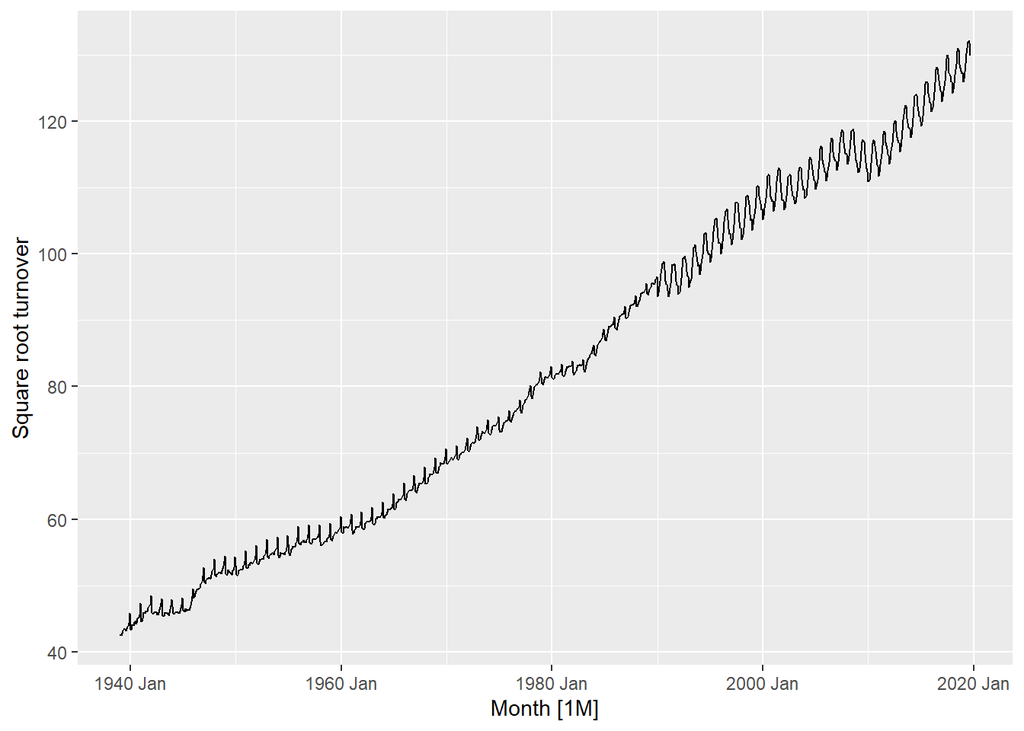

```r
us_employemnt_TS %>% autoplot(sqrt(Employed)) +
  labs(y = "Square root turnover")
```

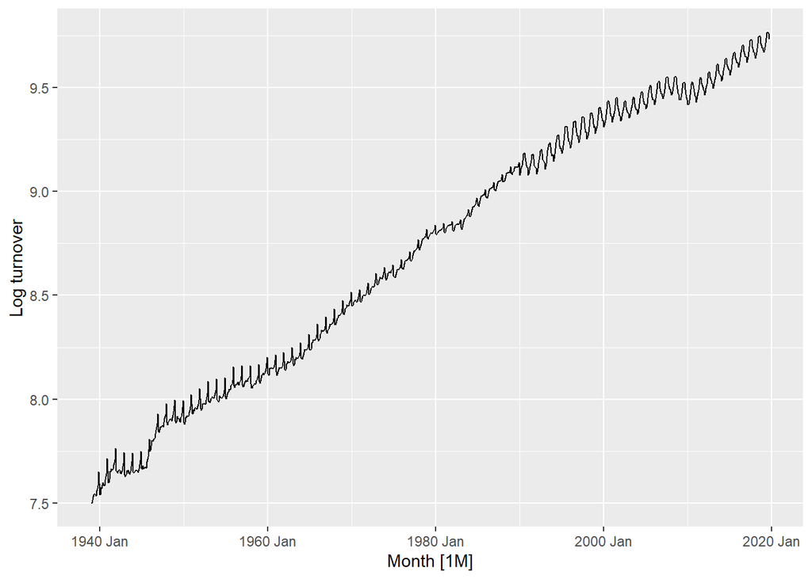

```r
us_employemnt_TS %>% autoplot(log(Employed)) +
  labs(y = "Log turnover")
```

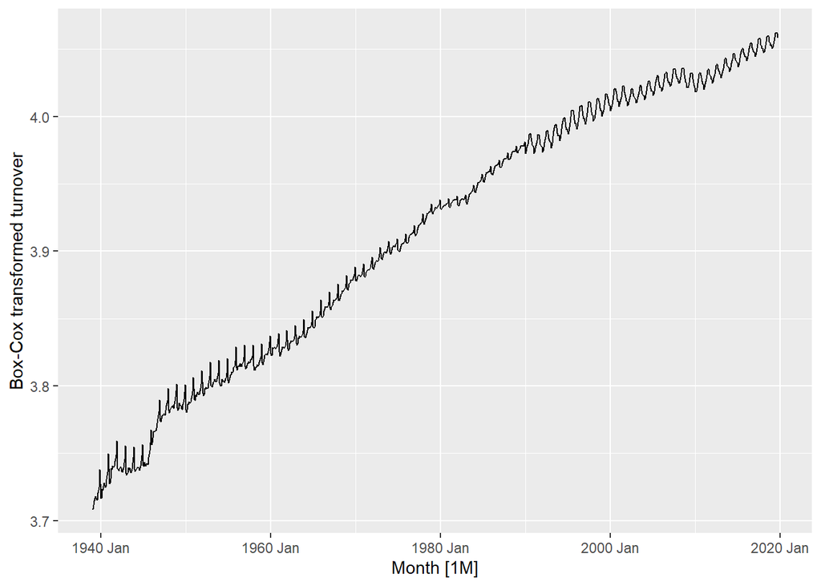

```r
us_employemnt_TS %>% autoplot(box_cox(Employed,-0.2164477)) +
  labs(y = "Box-Cox transformed turnover")
```

#Yes data needs transaformation.I could find that Box-cox and log are very similar but BoxCox is better, So I transfromed our data and stored into new variable.

```r
us_employemnt_Trans <- us_employemnt_TS %>%
  mutate(Employed = box_cox(Employed, lambda = -0.2164477))

head(us_employemnt_Trans)
```

| Month | Employed |
| --- | --- |
| 1939 Jan | 3.708702 |
| 1939 Feb | 3.708374 |
| 1939 Mar | 3.711623 |
| 1939 Apr | 3.714703 |
| 1939 May | 3.716689 |
| 1939 Jun | 3.717931 |

3. Are the data stationary? If not, find an appropriate differencing which yields stationary data.(4 points)

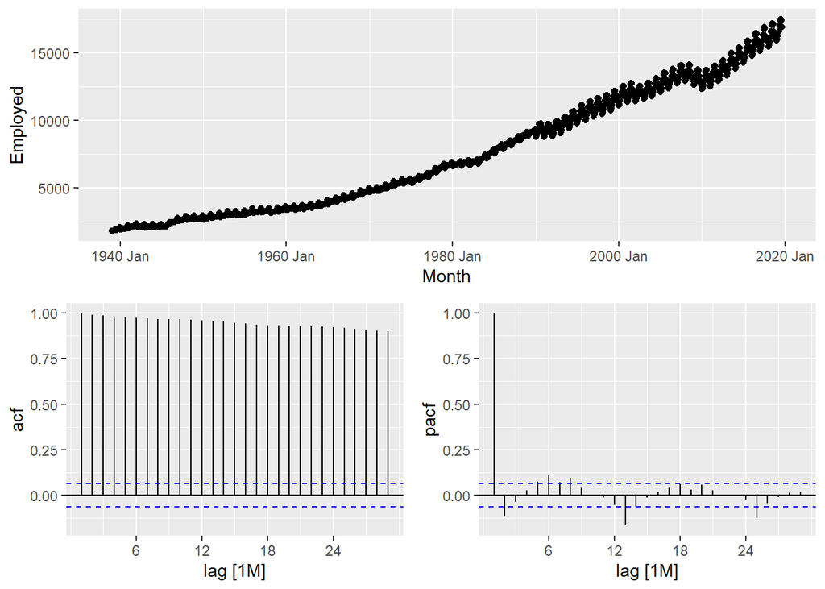

```r
#ACF & PCF plots
gg_tsdisplay(us_employemnt_TS,Employed,plot_type='partial')
```

```r
ndiffs(us_employemnt_TS$Employed,alpha=0.05)
```

```
## [1] 1
```

# As per my observations from PACF and ACF plots, I feel that data is not stationary. Also 1st differencing should be selected.

4. Identify a couple of ARIMA models that might be useful in describing the time series. Which of your models is the best according to their AICc values?(5 points)

```r
fit <- us_employemnt_Trans %>%
  model(
    arima_auto = ARIMA(Employed),
    #from ACF&pacf plot
    arima1 = ARIMA(Employed~0+pdq(12,1,0)+PDQ(1,0,0)),
    arima2 = ARIMA(Employed~0+pdq(2,1,2)+PDQ(0,1,2)),
    arima3 = ARIMA(Employed~0+pdq(2,1,0))
  )
accuracy(fit)
```

| .model | .type | ME | RMSE | MAE | MPE | MAPE | MASE | RMSSE | ACF1 |
| --- | --- | --- | --- | --- | --- | --- | --- | --- | --- |
| arima_auto | Training | -1.559337e-05 | 0.0009774773 | 0.0005733915 | -4.087356e-04 | 0.01483533 | 0.1255380 | 0.1721138 | 0.030562027 |
| arima1 | Training | 9.434933e-07 | 0.0009124318 | 0.0005665879 | 3.131521e-05 | 0.01466459 | 0.1240484 | 0.1606606 | 0.009820209 |
| arima2 | Training | -1.698049e-05 | 0.0009922436 | 0.0005764866 | -4.452435e-04 | 0.01492493 | 0.1262156 | 0.1747138 | 0.024572232 |
| arima3 | Training | -1.668243e-05 | 0.0009865090 | 0.0005825442 | -4.369229e-04 | 0.01508073 | 0.1275419 | 0.1737041 | 0.003304193 |

```r
report(fit[1])
```

```
## Series: Employed
## Model: ARIMA(1,1,2)(2,1,1)[12]
##
## Coefficients:
##          ar1      ma1     ma2     sar1     sar2    sma1
##       0.5861  -0.6248  0.2476  -1.0777  -0.4674  0.5957
## s.e.  0.0763   0.0755  0.0345   0.0668   0.0350  0.0699
##
## sigma^2 estimated as 9.746e-07:  log likelihood=5362.75
## AIC=-10711.5   AICc=-10711.39   BIC=-10677.47
```

```r
report(fit[2])
```

```
## Series: Employed
## Model: ARIMA(12,1,0)(1,0,0)[12]
##
## Coefficients:
##           ar1     ar2     ar3     ar4      ar5      ar6     ar7     ar8     ar9
##       -0.0811  0.1753  0.1469  0.0876  -0.0040  -0.0313  0.0020  0.0124  0.0157
## s.e.   0.0295  0.0295  0.0303  0.0306   0.0308   0.0308  0.0307  0.0308  0.0306
##         ar10    ar11     ar12    sar1
##       0.0234  0.1023  -0.4028  0.9927
## s.e.  0.0303  0.0296   0.0300  0.0026
##
## sigma^2 estimated as 8.447e-07:  log likelihood=5387.04
## AIC=-10746.08   AICc=-10745.64   BIC=-10677.83
```

```r
report(fit[3])
```

```
## Series: Employed
## Model: ARIMA(2,1,2)(0,1,2)[12]
##
## Coefficients:
##          ar1      ar2      ma1     ma2     sma1    sma2
##       0.6914  -0.1701  -0.7512  0.4173  -0.5077  0.0668
## s.e.  0.1376   0.1253   0.1281  0.1107   0.0327  0.0343
##
## sigma^2 estimated as 1.004e-06:  log likelihood=5345.93
## AIC=-10677.85   AICc=-10677.73   BIC=-10643.81
```

5. Estimate the parameters of your best model and do diagnostic testing on the residuals. Do the residuals resemble white noise? If not, try to find another ARIMA model which fits better.(5 points)

```r
final_model <- fit %>% select(arima1)
report(final_model)
```

```
## Series: Employed
## Model: ARIMA(12,1,0)(1,0,0)[12]
##
## Coefficients:
##           ar1     ar2     ar3     ar4      ar5      ar6     ar7     ar8     ar9
##       -0.0811  0.1753  0.1469  0.0876  -0.0040  -0.0313  0.0020  0.0124  0.0157
## s.e.   0.0295  0.0295  0.0303  0.0306   0.0308   0.0308  0.0307  0.0308  0.0306
##         ar10    ar11     ar12    sar1
##       0.0234  0.1023  -0.4028  0.9927
## s.e.  0.0303  0.0296   0.0300  0.0026
##
## sigma^2 estimated as 8.447e-07:  log likelihood=5387.04
## AIC=-10746.08   AICc=-10745.64   BIC=-10677.83
```

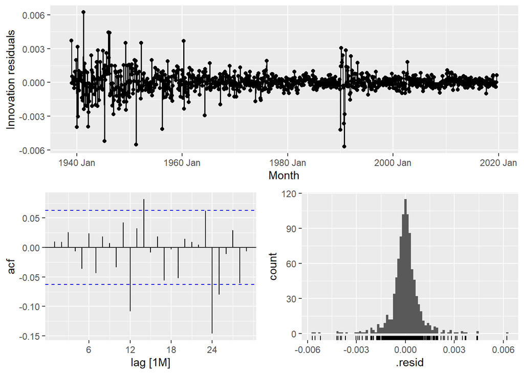

```r
gg_tsresiduals(final_model )
```

```r
augment(final_model) %>% features(.innov, ljung_box, lag=10, dof=2)
```

| .model | lb_stat | lb_pvalue |
| --- | --- | --- |
| arima1 | 6.05816 | 0.640717 |

6. Forecast the next 3 years of data. Get the latest figures from https://fred.stlouisfed.org/categories/11 to check the accuracy of your forecasts. (5 points)

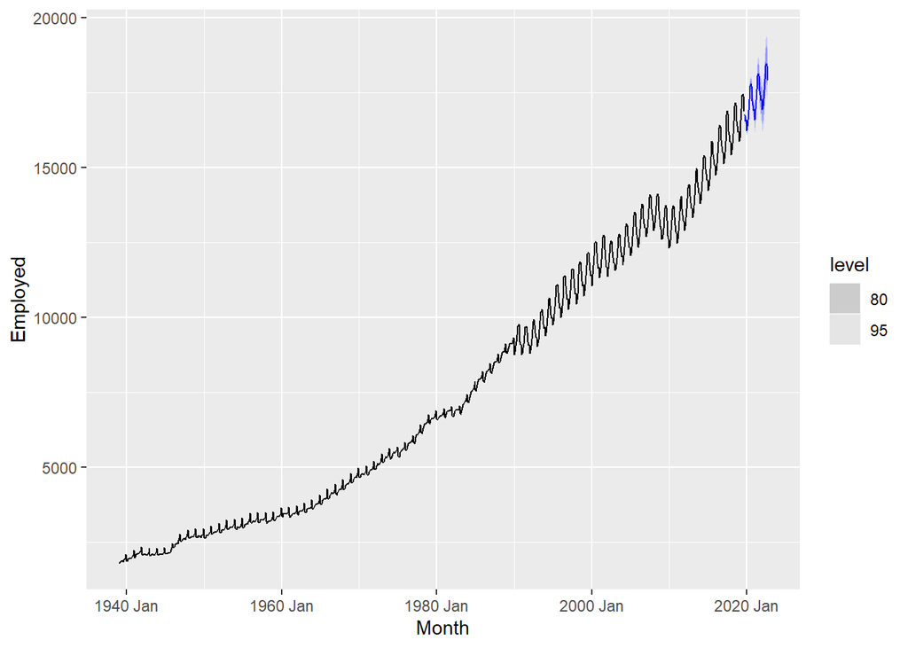

```r
arimafitt <- us_employemnt_TS%>%
model(
arima1 = ARIMA(Employed~0+pdq(12,1,0)+PDQ(1,0,0), stepwise = FALSE,approximation = FALSE)
)

ff <- forecast(arimafitt, h = 36)
ff %>% autoplot(us_employemnt_TS)
```

```r
#latest data
latest<- fread('CEU7000000001.csv')
head(latest)
```

| DATE | CEU7000000001 |
| --- | --- |
| 1939-01-01 | 1807 |
| 1939-02-01 | 1804 |
| 1939-03-01 | 1834 |
| 1939-04-01 | 1863 |
| 1939-05-01 | 1882 |
| 1939-06-01 | 1894 |

```r
latest %>%
  mutate(DATE = yearmonth(DATE)) %>%
  tsibble(index = DATE) -> latestts
latestts
```

| DATE | CEU7000000001 |
| --- | --- |
| 1939 Jan | 1807 |
| 1939 Feb | 1804 |
| 1939 Mar | 1834 |
| 1939 Apr | 1863 |
| 1939 May | 1882 |
| 1939 Jun | 1894 |
| 1939 Jul | 1873 |
| 1939 Aug | 1868 |
| 1939 Sep | 1920 |
| 1939 Oct | 1938 |

[output cut: 997 more lines]

```
## Plot variable not specified, automatically selected `.vars = CEU7000000001`
```

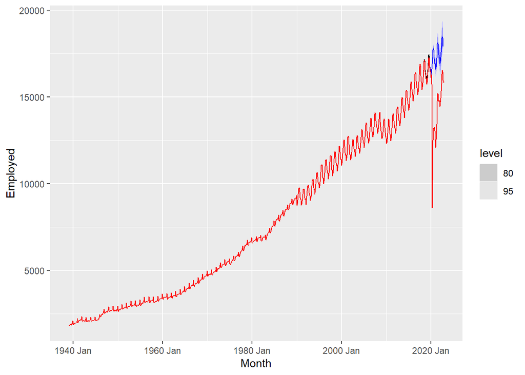

```r
ff %>% autoplot(us_employemnt_TS)+
autolayer(latestts, color = 'red')
```

7. Eventually, the prediction intervals are so wide that the forecasts are not particularly useful. How many years of forecasts do you think are sufficiently accurate to be usable? (3 points)

```r
#No I dont feel actual and predicted are accurate. It may be because of covid 19 which has impacted the hotel industry (in our case Leisure and hospitality) a lot. Lot of travel restrictions were imposed and that segment so huge losses due to that. I feel that actual data will helps to do the prediction in coming data.
```

# Part C (8 points)

## Consider following transactions:

1. Eggs, Bread, Milk, Bananas, Onion, Yogurt
2. Dill, Eggs, Bread, Bananas, Onion, Yogurt
3. Apple, Eggs, Bread, Milk
4. Corn, Bread, Milk, Teddy Bear, Yogurt
5. Corn, Eggs, Ice Cream, Bread, Onion

## a) Calculate by hand support, confidence and lift for following rules (without usage of apriory library, show your work)

### • {Bananas} -> {Yogurt} (2 points)

```
N= 5
N_bananas =2
N_yogurt = 3
N_bananas_yogurt =2

support  = 2/5
confidence = 2/2

support_yogurt = 3/5

lift = 2/2 / 3/5 = 5/3 which is [confidence/support_yogurt]
```

### • {Corn, Bread}->{Onion} (3 points)

[output not shown]

### • {Bread}->{Milk, Yogurt} (3 points)

```
N= 5
N_Bread = 5
N_Milk_Yogurt = 2
N_Bread_Milk_Yogurt = 2


support  = 2/5
confidence = 2/5

support_milk_yogurt = 2/5

lift = 2/5 / 2/5 = 1 which is [confidence/support_milk_yogurt]
```

# Part D (32 points)

Online_Retail2.csv contains transaction from online store in long format (i.e. single item per line and lines with same InvoiceNo is single transaction).

1. Read data and convert it to transactions (hint: transactions function and format argument). (4 points)

```r
order_data <- fread('Online_Retail2.csv')
order_data <- order_data %>%
  select(-CustomerID, -StockCode, -Country, -InvoiceDate)
head(order_data)
```

| InvoiceNo | Description | Quantity | UnitPrice |
| --- | --- | --- | --- |
| 536365 | WHITE HANGING HEART T-LIGHT HOLDER | 6 | 2.55 |
| 536365 | WHITE METAL LANTERN | 6 | 3.39 |
| 536365 | CREAM CUPID HEARTS COAT HANGER | 8 | 2.75 |
| 536365 | KNITTED UNION FLAG HOT WATER BOTTLE | 6 | 3.39 |
| 536365 | RED WOOLLY HOTTIE WHITE HEART. | 6 | 3.39 |
| 536365 | SET 7 BABUSHKA NESTING BOXES | 2 | 7.65 |

```r
order_trans <- transactions(order_data, format = 'long')
order_trans
```

```
## transactions in sparse format with
##  24446 transactions (rows) and
##  4211 items (columns)
```

```r
head(order_trans)
```

```
## transactions in sparse format with
##  6 transactions (rows) and
##  4211 items (columns)
```

2. Run summary on transactions. How many transactions are there? How many unique items? (4 points)

```r
summary(order_trans)
```

```
## transactions as itemMatrix in sparse format with
##  24446 rows (elements/itemsets/transactions) and
##  4211 columns (items) and a density of 0.005143444
##
## most frequent items:
## WHITE HANGING HEART T-LIGHT HOLDER           REGENCY CAKESTAND 3 TIER
##                               2302                               2169
##            JUMBO BAG RED RETROSPOT                      PARTY BUNTING
##                               2135                               1706
##            LUNCH BAG RED RETROSPOT                            (Other)
##                               1607                             519558
##
## element (itemset/transaction) length distribution:
## sizes
##    1    2    3    4    5    6    7    8    9   10   11   12   13   14   15   16
```

[output cut: 62 more lines]

```r
#For no of transactions
no_trans <- length(order_trans)


#For no of unique values
unique_items <- length(itemLabels (order_trans))


cat("No of Transactions:", no_trans, "\n")
```

```
## No of Transactions: 24446
```

```r
cat("Nuo of unique values:", unique_items, "\n")
```

```
## Nuo of unique values: 4211
```

3. Inspect (with inspect) first three transactions. What items are in basket with transaction id 536366? (4 points)

```r
inspect(order_trans[1:3,])
```

```
##     items                                  transactionID
## [1] {CREAM CUPID HEARTS COAT HANGER,
##      GLASS STAR FROSTED T-LIGHT HOLDER,
##      KNITTED UNION FLAG HOT WATER BOTTLE,
##      RED WOOLLY HOTTIE WHITE HEART.,
##      SET 7 BABUSHKA NESTING BOXES,
##      WHITE HANGING HEART T-LIGHT HOLDER,
##      WHITE METAL LANTERN}                         536365
## [2] {HAND WARMER RED POLKA DOT,
##      HAND WARMER UNION JACK}                      536366
## [3] {ASSORTED COLOUR BIRD ORNAMENT,
##      BOX OF 6 ASSORTED COLOUR TEASPOONS,
##      BOX OF VINTAGE ALPHABET BLOCKS,
##      BOX OF VINTAGE JIGSAW BLOCKS,
##      DOORMAT NEW ENGLAND,
##      FELTCRAFT PRINCESS CHARLOTTE DOLL,
##      HOME BUILDING BLOCK WORD,
##      IVORY KNITTED MUG COSY,
##      LOVE BUILDING BLOCK WORD,
##      POPPY'S PLAYHOUSE BEDROOM,
##      POPPY'S PLAYHOUSE KITCHEN,
##      RECIPE BOX WITH METAL HEART}                 536367
```

#In the order with transaction id 536366 we have follwoing items HAND WARMER RED POLKA DOT, and HAND WARMER UNION JACK. d) Visualize top 10 frequent items. What is the most frequent? (4 points)

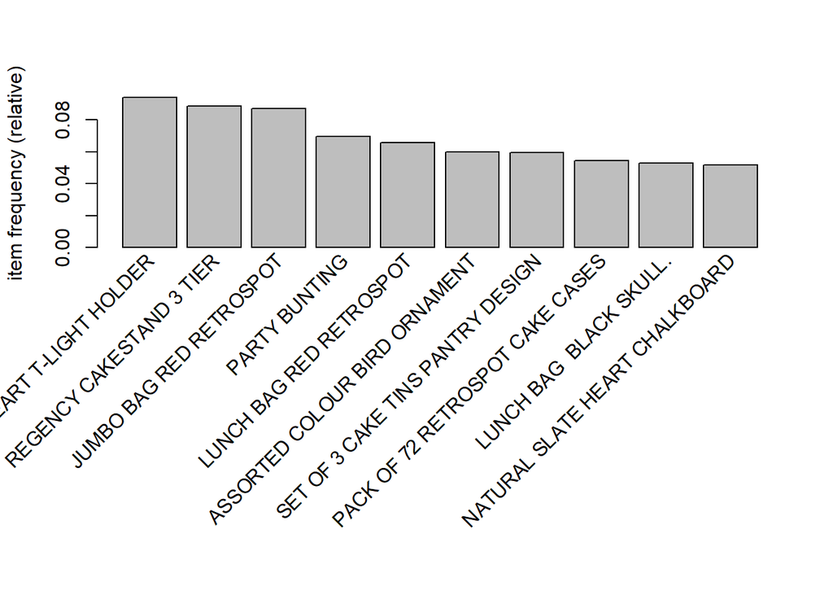

```r
itemFrequencyPlot(order_trans,topN=10)
```

#Most frequent as per plot is WHITE HANGING HEART T-LIGHT HOLDER. e) We want to look at rule which would have at least 100 transactions. What support is corresponding to that? (4 points)

```r
temp <- 100/nrow(order_trans)
cat(temp)
```

```
## 0.004090649
```

6. Calculate rules with a rule. Use previously calculated support, confidence of 0.9 and maxlen of 4 (we are looking into the rules with up to 4 items). (4 points)

```r
items <- apriori(order_trans,parameter=list(support=0.0041,confidence=0.9,maxlen =4))
```

```
## Apriori
##
## Parameter specification:
##  confidence minval smax arem  aval originalSupport maxtime support minlen
##         0.9    0.1    1 none FALSE            TRUE       5  0.0041      1
##  maxlen target  ext
##       4  rules TRUE
##
## Algorithmic control:
##  filter tree heap memopt load sort verbose
##     0.1 TRUE TRUE  FALSE TRUE    2    TRUE
##
## Absolute minimum support count: 100
##
## set item appearances ...[0 item(s)] done [0.00s].
## set transactions ...[4211 item(s), 24446 transaction(s)] done [0.15s].
## sorting and recoding items ... [1558 item(s)] done [0.01s].
## creating transaction tree ... done [0.01s].
## checking subsets of size 1 2 3 4
```

```
##  done [0.11s].
## writing ... [1216 rule(s)] done [0.00s].
## creating S4 object  ... done [0.00s].
```

```r
items
```

```
## set of 1216 rules
```

#So we have 1216 rules. g) List top 10 by confidence. What is the sense of confidence (explain on example of the top rule)? (4 points)

```r
inspect(head(sort(items,by='confidence'),n=10))
```

```
##      lhs                                       rhs                  support confidence    coverage     lift count
## [1]  {CHRISTMAS TREE HEART DECORATION,
##       SUKI  SHOULDER BAG}                   => {DOTCOM POSTAGE} 0.004131555          1 0.004131555 34.47955   101
## [2]  {PIZZA PLATE IN BOX,
##       SUKI  SHOULDER BAG}                   => {DOTCOM POSTAGE} 0.004417901          1 0.004417901 34.47955   108
## [3]  {SKULL SHOULDER BAG,
##       URBAN BLACK RIBBONS}                  => {DOTCOM POSTAGE} 0.004172462          1 0.004172462 34.47955   102
## [4]  {RECYCLING BAG RETROSPOT,
##       SET/4 RED MINI ROSE CANDLE IN BOWL}   => {DOTCOM POSTAGE} 0.004295181          1 0.004295181 34.47955   105
## [5]  {SET/4 RED MINI ROSE CANDLE IN BOWL,
##       SUKI  SHOULDER BAG}                   => {DOTCOM POSTAGE} 0.004540620          1 0.004540620 34.47955   111
## [6]  {CHRISTMAS TREE STAR DECORATION,
##       SKULL SHOULDER BAG}                   => {DOTCOM POSTAGE} 0.004295181          1 0.004295181 34.47955   105
## [7]  {BEADED CRYSTAL HEART GREEN ON STICK,
##       VINTAGE PAISLEY STATIONERY SET}       => {DOTCOM POSTAGE} 0.004540620          1 0.004540620 34.47955   111
## [8]  {BEADED CRYSTAL HEART GREEN ON STICK,
##       FLORAL FOLK STATIONERY SET}           => {DOTCOM POSTAGE} 0.004867872          1 0.004867872 34.47955   119
## [9]  {BEADED CRYSTAL HEART GREEN ON STICK,
##       CHARLOTTE BAG SUKI DESIGN}            => {DOTCOM POSTAGE} 0.004131555          1 0.004131555 34.47955   101
## [10] {BEADED CRYSTAL HEART GREEN ON STICK,
##       SUKI  SHOULDER BAG}                   => {DOTCOM POSTAGE} 0.004745153          1 0.004745153 34.47955   116
```